# Cross-section Integration: DLPFC

# Overview

This R Markdown document runs a cross-section integration workflow using the **DaVinci** package on multiple DLPFC slices. It includes preprocessing, cross-section integration, visualization of latent variables, and clustering. Adjust file paths, parameters, and plotting options to suit your environment and desired level of detail.

## Setup

Load required packages and set the working directory. Change the `setwd()` path to where your `data/` folder is located if necessary.

```r
library(DaVinci)
library(ggpubr)

setwd("~/For_Tutorial/DLPFC/")
```

## Configuration

Set minimal configuration options for preprocessing. `normalize.version` controls preprocessing choices (e.g., `gene` for RNA, or several `LSI_*` options for ATAC-like preprocessing).

```r
normalize.version <- "gene"  # options: "gene", "LSI_1", "LSI_2", "LSI_3"
```

## Load data & preprocess per sample

This section reads RDS files from `data/`. Each RDS file should contain at least `mat` (gene-by-spot matrix of raw counts) and `coor` (spot-by-(x,y) coordinate matrix with columns `array_row` and `array_col`). The loop preprocesses each sample according to `normalize.version` and stores results in `Y.list`, `L.list`, and `coor.list`.

```r
data.dir <- "~/For_Tutorial/DLPFC/data/"

file.list <- list.files(data.dir)
file.list <- file.list[grepl(".RDS", file.list)]
dataset.opts <- gsub(".RDS", "", file.list)

Y.list <- list()
L.list <- list()
coor.list <- list()

for (ii in seq_along(dataset.opts)) {
  input.file <- paste0(data.dir, file.list[ii])
  input <- readRDS(input.file)

  mat <- input$mat
  coor <- input$coor

  if (normalize.version == "gene") {
    fin <- preprocess(mat,
                      coor,
                      type = "rna",
                      graph.opt = "Tri.mesh",
                      frac.thr = 0.95)

  } else if (normalize.version == "LSI_1") {
    fin <- preprocess(mat,
                      coor,
                      type = "atac",
                      graph.opt = "Tri.mesh",
                      LSI.method = "1",
                      LSI.scale.factor = 1e5,
                      LSI.peak.filter.thr = 0.95)

  } else if (normalize.version == "LSI_2") {
    fin <- preprocess(mat,
                      coor,
                      type = "atac",
                      graph.opt = "Tri.mesh",
                      LSI.method = "2",
                      LSI.scale.factor = 1e5,
                      LSI.peak.filter.thr = 0.95)

  } else if (normalize.version == "LSI_3") {
    fin <- preprocess(mat,
                      coor,
                      type = "atac",
                      graph.opt = "Tri.mesh",
                      LSI.method = "3",
                      LSI.scale.factor = 1e5,
                      LSI.peak.filter.thr = 0.95)
  }

  Y.list[[ii]] <- fin$mat
  L.list[[ii]] <- fin$L
  coor.list[[ii]] <- fin$coor
}
```

## Quick demo: subset of the sections

For a quick demo run or debugging, we restrict to the first two sections. Remove or modify this section to run on all samples.

```r
dataset.opts <- dataset.opts[1:2]
Y.list <- Y.list[1:2]
L.list <- L.list[1:2]
coor.list <- coor.list[1:2]
```

## Cross-section integration

This step achives the cross-section integration via a wrapper function `Horizontal.Integration.Assemble`. `k.arg.list` is a list of candidate numbers of latent variables for identifying robust latent variables. The example uses a short list for demo. **Note:** The wrapper function `Horizontal.Integration.Assemble` is readily parallelizable and will be implemented in a future release.

```r
HI.res <- Horizontal.Integration.Assemble(
  dataset.opts = dataset.opts,
  Y.list  = Y.list,
  L.list  = L.list,
  coor.list = coor.list,
  k.arg.list = c(4, 6, 8)  # candidate k values; extend if needed
)
```

## Extract integrated latent matrix and section mapping

`HI.res$mat` contains integrated latent variables, and `HI.res$mat.slice.id` maps each column/spot to its original section. We’ll use these for clustering and visualization.

```r
mat <- HI.res$mat
mat.slice.id <- HI.res$mat.slice.id
```

## Visualize latent variables by section

Use `scatter.FeaturePlot.list()` to visualize latent variable patterns across sections. The first call displays everything on a single page. The second call returns individual plot objects for further arrangement or saving.

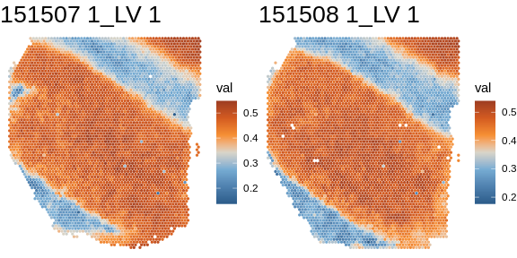

```r
#visualize everything on the same page directly
#scatter.FeaturePlot.list(mat, coor.list, mat.slice.id, dataset.opts)

names(coor.list) <- dataset.opts

# visualize separately by LV (returns list of plots)
plot.list <- scatter.FeaturePlot.list(mat,
                                      coor.list,
                                      mat.slice.id,
                                      dataset.opts,
                                      pt.size = 0.5,
                                      return.obj = TRUE, single.obj = FALSE,
                          orientation = "y-x")

#Arrange first LV across sections
ggarrange(plotlist = plot.list[[1]])
```

## Inspect loadings

The `HI.res$integration.res$loading` object contains gene loadings associated with each LV.

```r
loading <- HI.res$integration.res$loading
# Example: show top 20 genes for the first sample and first LV (if present)

if (!is.null(loading) && length(loading) >= 1) {
  print(head(sort(loading[[1]], decreasing = TRUE), 20))
}
```

```
##       MT3      FTH1      NRGN    TMSB10    SNAP25     GAPDH    TUBA1B     RPL41
##  5.522070  5.467922  5.227789  5.057061  5.042069  4.852574  4.753459  4.623404
##    NDUFA4      ACTB     CALM1     CALM2    TMSB4X      GNAS MTRNR2L12      CST3
##  4.535037  4.452251  4.407392  4.359039  4.235338  4.223202  4.195873  4.187074
##       CKB     YWHAH     VSNL1     COX6C
##  4.138137  4.128868  4.070693  4.013206
```

## Clustering options (multiple workflows)

DaVinci provides multiple clustering workflows. We demonstrate three options: Louvain clustering with resolution sweep, Louvain with direct number-of-clusters control, and mclust. After clustering, an optional refinement step `Niche.report.finetune()` smooths clusters spatially.

### Option 1: Louvain clustering (resolution sweep)

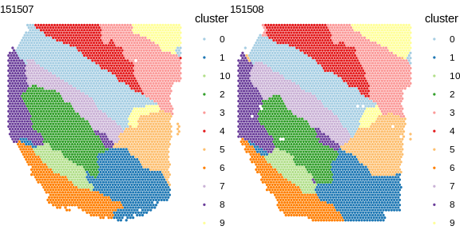

```r
res.niche <- Niche.report(mat,
                          method = "louvain",
                          L2.opt = TRUE,
                          resolution.args = c(0.5, 1), verbose = FALSE)

res.niche.refine <- Niche.report.finetune(res.niche$niche.list, dataset.opts, coor.list, mat.slice.id)

# visualize refined clusters (example using resolution = 0.5)
cluster.RNA <- res.niche.refine[[1]]
scatter.DiscretePlot.list(cluster.RNA,
                          coor.list,
                          mat.slice.id,
                          dataset.opts,
                          pt.size = 0.5,
                          orientation = "y-x")
```

### Option 2: Louvain clustering (fixed number of clusters)

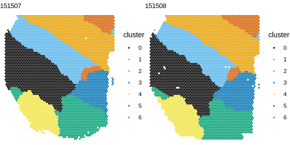

```r
res.niche <- Niche.report(mat,
                          method = "louvain",
                          L2.opt = TRUE,
                          num.cluster.args = c(7, 10), verbose = FALSE)
res.niche.refine <- Niche.report.finetune(res.niche$niche.list, dataset.opts, coor.list, mat.slice.id)

cluster.RNA <- res.niche.refine[[1]]
scatter.DiscretePlot.list(cluster.RNA,
                          coor.list,
                          mat.slice.id,
                          dataset.opts,
                          pt.size = 0.5,
                          orientation = "y-x")
```

### Option 3: mclust

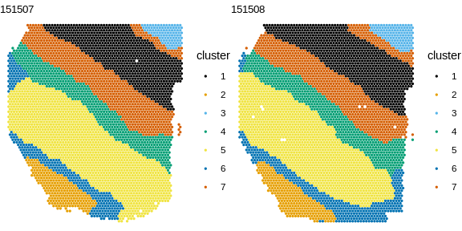

```r
res.niche <- Niche.report(mat,
                          method = "mclust",
                          L2.opt = TRUE,
                          num.cluster.args = c(7, 10),
                          verbose = FALSE)
res.niche.refine <- Niche.report.finetune(res.niche$niche.list, dataset.opts, coor.list, mat.slice.id)

cluster.RNA <- res.niche.refine[[1]]
scatter.DiscretePlot.list(cluster.RNA,
                          coor.list,
                          mat.slice.id,
                          dataset.opts,
                          pt.size = 0.5,
                          orientation = "y-x")
```